# Mi primer documento con R en el prope

Dr. Oscar V. De la Torre-Torres

09 de marzo del 2021

# Introducción

En este archivo de R markdown se aprendió, por un lado, cómo hacer documentos y compilarlos con Rstudio y, luego, cómo programar y correr instrucciones (**programas**) para *nuestro análisis*.

En el siguiente fragmento de código, se van a crear 2 objetos (vectores columna) llamados **dado** y **Dado**.

```r
# Creamos un objeto llamado dado, el cual tiene los resultados posibles de un dado:
dado=c(1,2,3,4,5,6)

# Creamos un objeto llamado Dado, el cual tinene los mismos valores del objeto dado previo pero se llama diferente:
Dado=c(1,2,3,4,5,6)

# Creamos un objeto llamado Dado.copion que le copia los valores al objeto Dado:
Dado.copion=Dado

dado
```

```
## [1] 1 2 3 4 5 6
```

En el siguiente fragmento de código (programa), se crea un objeto llamado Dado.cubilete que tiene los posibles resultados del dado. El mismo, es un objeto ya no numérico como los anteriormente creados, sino texto. Inclusoi, este chunk no aparecerá y solo aparecerán las figuras del dado en la pantalla.

```
## [1] "As"          "Rey"         "Reina"       "Sota"        "8 diamantes"
## [6] "7 espadas"
```

## Gráficas

En el siguiente código vamos a crear una gráfica simple (muy fea pero útil) de 100 números aleatorios que están distribuidos gaussianamente con una media de $\mu=3$ y una desviación estándar $\sigma=2.5$. En este caso queremos el código y la gráfica.

VEamos cómo generar y presentar solamente los datos (sin tabla de manera fea):

```r
# Se generan los 100 números aleatorios conforme se indicó.
# Se crea un objeto con el valor de la media:
mu=3
# Se crea un objeto con el valor de la desv. est.:
sigma=2.5

# Se crea el vector columna con los 100 números aleatorios gaussianamente distribuidos:
x.gauss=rnorm(100,mean=mu,sd=sigma)

x.gauss
```

```
##   [1]  3.629742176  3.752922856  3.190857153 -0.244202851  3.570159882
##   [6]  1.856100404  3.094320581  5.569017565  3.034621561  4.876256698
##  [11]  2.469491279  5.783869212  7.441425972  1.501856223 -0.810154522
##  [16]  6.788121014  2.832924195  1.088945069  6.453422185  1.127860792
##  [21]  5.182073171  2.523388316  3.535764961  0.973455609  9.171151153
##  [26]  1.778209599  2.817940772  4.568213895  4.266477170  0.122739524
##  [31]  1.925865674  3.514893843  5.022343437  1.194375883  0.477994155
##  [36]  2.450170475  2.414107962 -0.584898053  0.724809837 -0.005849213
##  [41]  7.442214632  5.532142593  1.452117153  2.145160086  5.972146247
##  [46]  0.097572346  2.627995891 -0.939043289  0.351863976  1.028589684
##  [51]  4.576237694  6.428579381  3.587214469 -2.015662402  2.368534398
##  [56]  4.668131310  5.367305747  4.967641284 -0.672497783  0.962967489
##  [61] -1.937262319  2.503433309  2.765191965  0.454125068  1.398444665
##  [66]  3.826624927  3.859271998  1.685443164 -1.176741748  5.534470898
##  [71] -2.125475731  2.774960408  4.327450005  7.755358926  3.288133060
##  [76] -0.639398412  4.269678626  0.490371234  4.650285808  2.108059753
##  [81]  4.898472815  0.362630285  8.558459484  6.577536755  4.279166807
##  [86]  3.091011017 -0.898891153  6.372838100  1.868591175  4.878019232
##  [91]  6.585673930  3.058237729  2.386464570 -4.791964726  1.583112722
##  [96]  2.445716149 -0.673972906  1.265846083  1.145184239  2.170606448
```

Ahora vamos a hacer la gráfica y solo apracerá la misma (el código no):

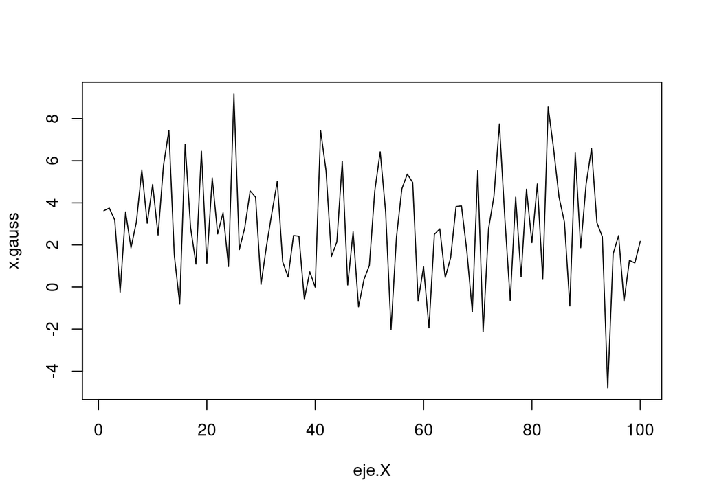